Collections

This is a notebook used as 'slides' for the class 3 on **collections**

# Intro: sequences, sets, dictionaries

A collection is a data type able to store 0, 1 or more elements. This is particularly useful to

- Structure your data
- Easily access elements in collections of data of *same type*

For example you might want to have:

| Type | Description |
| --- | --- |
| **Sequence types** | An ordered list of all the assignments of this course |
| **Set types** | An unordered collection without replicas (a set) of the students of this course |
| **Map/Dictionary types** | A mapping from the name of a student to the email of that student |

> Note: in jupyter you can create tables. [There are also online table generators](https://www.tablesgenerator.com/markdown_tables)

# Sequence types

There are [3 basic sequence types in Python](https://docs.python.org/3/library/stdtypes.html#sequence-types-list-tuple-range)

- String
- **List**
- **Tuple**
- **Range**

## Strings

[We have already seen](https://htmlpreview.github.io/?https://github.com/andrea-vandin/IntroToPython20192020/blob/master/jupyter/jupyterNotebooks/02DataTypesAndOperations.html) that a string can be used also as a sequence of characters.

```python
s="abcd"
print(s[1])
print(s[-1])
print(s[2:])
print(s[:2])
print(s[2:4])
print(s + "efg")
print(min(s))
print(max(s))
```

```
b
d
cd
ab
cd
abcdefg
a
d
```

A string is a *special* sequence

- A string is **immutable**

  > `s[1] = 'B'` __WE CAN'T MODIFY ENTRIES OF A STRING!__
- The only elements admitted in a string are characters

```python
# If you decomment the line below you will get a runtime error
# s[1] = 'B'
```

## Lists, Tuples, and Ranges

### Lists

Intuitively, a list is like a string, but you can store in it data of any type, even of mixed types

- But you will typically put elements of same type in a list
- Functionalities related to comparsions work only on lists with elements of same type
  - E.g. min/max/sort ...

You create a list by writing a comma-separated list of values in square brackets

```python
lst = [12, 'apples', 12.0, 'pears', True]
print(type(lst))
print(lst)
```

```
<class 'list'>
[12, 'apples', 12.0, 'pears', True]
```

You can access the elements of a list similarly to how you access characters of a string:

```python
print(lst)
print(len(lst))
print(lst[1])
print(lst[-1])
print(lst[-2])
print(lst[:2])
print(lst[2:])
```

```
[12, 'apples', 12.0, 'pears', True]
5
apples
True
pears
[12, 'apples']
[12.0, 'pears', True]
```

```python
lst0 = [1,2,3,4]
print(lst0)
print(min(lst0))
print(max(lst0))
```

```
[1, 2, 3, 4]
1
4
```

Similarly to strings, we can concatenate lists...

```python
lst2 = [1,2,3,"four"]
lst3 = lst + lst2
print(lst3)
```

```
[12, 'apples', 12.0, 'pears', True, 1, 2, 3, 'four']
```

```python
tenzeros = [0] * 10
print(tenzeros)
```

```
[0, 0, 0, 0, 0, 0, 0, 0, 0, 0]
```

Pay attention when you use * on lists containing complex data types.

```python
lists = [[]] * 3
print(lists)
```

```
[[], [], []]
```

```python
lists[0].append(3)
print(lists)
```

```
[[3], [3], [3]]
```

Unexpected behavior:

- The same empty list is copied 3 times.
- Changing the list pointed in one entry changes the same list pointed by the other entries

This is a **shallow copy** of the empty lists. If you want different instances of you can use:

```python
lists = [[] for i in range(3)]
lists[0].append(3)
print(lists)
```

```
[[3], [], []]
```

Lists containing elements of **same type** can be compared

- The comparison is done in lexicographical order

```python
lst4=[1,2,3,3]
print(lst4,'<',lst0)
print(lst4<lst0)
```

```
[1, 2, 3, 3] < [1, 2, 3, 4]
True
```

### Lists features beyond strings

However, now we can also

- update entries of a list
- create use a list as an element of another list
  - have you ever heard about matrices?

| 0 | 1 | 2 |
| --- | --- | --- |
| 3 | 4 | 5 |

```python
m=[[0,1,2],[3,4,5]]
print('First row',m[0])
print('Second row',m[1])
print('First element of first row',m[0][0])
print('Third element of second row',m[1][2])
```

```
First row [0, 1, 2]
Second row [3, 4, 5]
First element of first row 0
Third element of second row 5
```

```python
print(lst)
lst[0]=11
lst[1]=4.3
print(lst)
```

```
[12, 'apples', 12.0, 'pears', True]
[11, 4.3, 12.0, 'pears', True]
```

```python
lst4 = [lst, lst2, lst3]
print(lst4)
```

```
[[11, 4.3, 12.0, 'pears', True], [1, 2, 3, 'four'], [12, 'apples', 12.0, 'pears', True, 1, 2, 3, 'four']]
```

How can I access the first element of the second list in `lst4`?

```python
secondlist = lst4[1]
firstelement = secondlist[0]
print(firstelement)
# or ...
print(lst4[1][0])
```

```
1
1
```

Lists can have any level of nesting in other lists, and can be mixed with other types

```python
lst5 = [lst4 , [1,2], 1, "ciao", True ]
print(lst5)
#Print the same as 'firstelement' from above
print(lst5[0][1][0])
```

```
[[[11, 4.3, 12.0, 'pears', True], [1, 2, 3, 'four'], [12, 'apples', 12.0, 'pears', True, 1, 2, 3, 'four']], [1, 2], 1, 'ciao', True]
1
```

### How to copy a list?

```python
l1=[1,2,3,4]
l2=l1
print(l2)
l1[0]=100
print(l2)
```

```
[1, 2, 3, 4]
[100, 2, 3, 4]
```

In the example before l1 and l2 point to the same list. This is a *shallow copy*

How to really copy a list into a new one?

- Use list constructor
- Use list comprehension

```python
#Using the constructor of lists
l2=list(l1)
l1[0]=200
print(l2)
```

```
[100, 2, 3, 4]
```

```python
#Using list comprehensions
l2=[x for x in l1]
l1[0]=300
print(l2)
```

```
[200, 2, 3, 4]
```

Anything that can be *iterated* can be used in the examples above to construct lists

- Any sequence and more iterable objects we will discuss later in the course

```python
l2 = list("ciao")
print(l2)
l2 = [x for x in "hello"]
print(l2)
```

```
['c', 'i', 'a', 'o']
['h', 'e', 'l', 'l', 'o']
```

### Interesting operations and methods in lists

```python
lst = [12, 15, 1, 0,1.0]
print('Does 1 appear in lst?',1 in lst)
print('Does 1 not appear in lst?',1 not in lst)
print('Does 2 appear in lst?',2 in lst)
print('Does the string \'1\' appear in lst?','1' in lst)
```

```
Does 1 appear in lst? True
Does 1 not appear in lst? False
Does 2 appear in lst? False
Does the string '1' appear in lst? False
```

Note that in the latter `'1' in lst` we check if the string `'1'` belong to `lst`.

- Thus is not the case, because `lst` contains only nnumeric types

```python
dir(lst)
```

```
['__add__',
 '__class__',
 '__contains__',
 '__delattr__',
 '__delitem__',
 '__dir__',
 '__doc__',
 '__eq__',
 '__format__',
 '__ge__',
 '__getattribute__',
 '__getitem__',
 '__gt__',
 '__hash__',
 '__iadd__',
 '__imul__',
 '__init__',
 '__init_subclass__',
 '__iter__',
 '__le__',
 '__len__',
 '__lt__',
 '__mul__',
 '__ne__',
 '__new__',
 '__reduce__',
 '__reduce_ex__',
 '__repr__',
 '__reversed__',
 '__rmul__',
 '__setattr__',
 '__setitem__',
 '__sizeof__',
 '__str__',
 '__subclasshook__',
 'append',
 'clear',
 'copy',
 'count',
 'extend',
 'index',
 'insert',
 'pop',
 'remove',
 'reverse',
 'sort']
```

```python
help(lst.insert)
```

```
Help on built-in function insert:

insert(index, object, /) method of builtins.list instance
    Insert object before index.
```

Some interesting methods:

- append: adds an object at the end of the list
- pop: removes the last element from the list
- insert: adds an object in a given position
- copy: creates a copy of the list
- remove: removes the first occurrence of a given object from the list
- count: counts the number of occurrences of an object
- index: gives the position of the first occurrence of an object
- reverse: reverses the elements from last to first
- sort: sorts the list

```python
lst = [12, 15, 1, 0,1.0]
print('We start from:')
print(lst)

lst.append(100)
print('append(100)')
print(lst)

lst.pop()
print('pop')
print(lst)

lst.insert(0,100)
print('insert(0,100)')
print(lst)

lst.insert(3,100)
print('insert(3,100)')
print(lst)

lst.remove(100)
print('remove(100)')
print(lst)

print('Number 1 appears',lst.count(1),'times in lst')
print('Number 1 appears first in index',lst.index(1),'in lst')
#You can't asks for the index of an element if it does not belong to the list.
#If you uncomment this statement you get a runtime error.
#lst.index(2)

lst.reverse()
print('Reverse')
print(lst)

lst.sort()
print('Sort')
print(lst)
```

```
We start from:
[12, 15, 1, 0, 1.0]
append(100)
[12, 15, 1, 0, 1.0, 100]
pop
[12, 15, 1, 0, 1.0]
insert(0,100)
[100, 12, 15, 1, 0, 1.0]
insert(3,100)
[100, 12, 15, 100, 1, 0, 1.0]
remove(100)
[12, 15, 100, 1, 0, 1.0]
Number 1 appears 2 times in lst
Number 1 appears first in index 3 in lst
Reverse
[1.0, 0, 1, 100, 15, 12]
Sort
[0, 1.0, 1, 12, 15, 100]
```

```python
help(lst.index)
```

```
Help on built-in function index:

index(value, start=0, stop=9223372036854775807, /) method of builtins.list instance
    Return first index of value.

    Raises ValueError if the value is not present.
```

```python
lst2 = lst+["ciao"]
print(lst2)
# You can't do certain operations on lists with elements of different types
#sort(lst2)
#min(lst2)
#max(lst2)
```

```
[0, 1.0, 1, 12, 15, 100, 'ciao']
```

> `sort(lst2)` __OPERATIONS REGARDING COMPARISONS ARE FORBIDDEN ON MULTI-TYPE LISTs__

### Tuples: an **immutable** version of lists

Tuples are another sequence type.

- They are essentially lists whose we cannot modify
- The are created using rounded parenthesis rather than squared ones

```python
tpl = (1,2,4,10,20)
print(type(tpl))
print(tpl)
#Parennthesis are optional
tpl = 1,2,4,10,20
print(tpl)

tpl2 = tuple(tpl)
print(tpl2)
lst = [1,2,3]
tpl3 = tuple(lst)
print(lst,tpl3)
```

```
<class 'tuple'>
(1, 2, 4, 10, 20)
(1, 2, 4, 10, 20)
(1, 2, 4, 10, 20)
[1, 2, 3] (1, 2, 3)
```

```python
print(len(tpl))
print(tpl[1])
print(tpl[-1])
print(tpl[:2])
print(tpl[2:])
```

```
5
2
20
(1, 2)
(4, 10, 20)
```

> `tpl[1] = 10` __NOT GOOD!__

Tuples implement the non-modifying operations shown for lists

- in, not in, min, max, ...

Why are tuples useful?

- Sometimes it is convenient to have the guarantee that data cannot change.
- They can be used as keys in dictionaries (more on this later today)
- Lists are typically meant for collecting homogeneous types, while tuples for heterogeneous types

### Ranges & list comprehensions

Ranges are another form of immutable sequence

- In the next class we will see that they are mainly used to iterate over certain instructions a given number of times

```python
s=range(10)
print(type(s))
print(s)
print(s[0])
print(s[1])
print(s[2])
print(s[3])
print(s[4])
print(s[5])
print(s[6])
print(s[7])
print(s[8])
print(s[9])
```

```
<class 'range'>
range(0, 10)
0
1
2
3
4
5
6
7
8
9
```

```python
start=11
stop=20
step=2
#Creates a sequence a number start,start+step,start+step*2,... up to stop-1
s=range(start,stop,step)
print(s[0])
print(s[1])
print(s[2])
print(s[3])
print(s[4])
#Number 'stop' does not belong to the collection
print(stop in s)
#print(s[5])
```

```
11
13
15
17
19
False
```

We can use ranges to easily build lists or tuples

```python
t= tuple(range(10))
l = list(range(10))
l2 =[ x for x in range(10)]
l3 =[ x for x in range(10) if x>2 and x< 8]
l4 =[ x*x for x in range(10)]
print(l)
print(l2)
print("        ",l3)
print(l4)
```

```
[0, 1, 2, 3, 4, 5, 6, 7, 8, 9]
[0, 1, 2, 3, 4, 5, 6, 7, 8, 9]
         [3, 4, 5, 6, 7]
[0, 1, 4, 9, 16, 25, 36, 49, 64, 81]
```

The `[x+1 for x in range(10) if x>2]` is a **list comprehension**

- Allows you to build a list manipulatinng and filtering ranges or other sequences

## A first taste of plots

Not all Python modules are distributed directly in the Python distribution. Some, like **matplotlib** that allows you to **create plots**, are not.

> **The first time you run jupyter you have to install it using the following script**

```python
#import sys
#!{sys.executable} -m pip install matplotlib
```

```python
#If you have installed matplotlib, you can import part of it.
import matplotlib.pyplot as plt
#If you want more info on this module
#help(plt)
```

Maybe you never thought about, but when you plot you use two sequences of data

```python
x=[1, 2, 3, 4]
y=[1, 2, 3, 4]
```

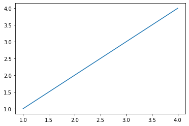

```python
#Creating a simple plot is... simple :)
plt.plot(x,y)
plt.show()
```

The idea is the following

1. `plt` is your plot. You can modify at please.
2. When the plot is ready, you can draw it using `plt.show()`
3. When you draw the plot, plt is 'cleared'

```python
#If you want more details on the method plot
#help(plt.plot)
```

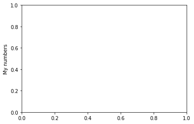

```python
plt.ylabel('My numbers')
plt.show()
```

We can modify the plot, e.g.

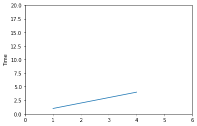

```python
plt.plot(x,y)
plt.ylabel('My numbers')
plt.ylabel('Time')
plt.axis([0, 6, 0, 20])
plt.show()
```

We can

- plot more lines, with different styles
  - same as matlab
- add text and graphics to the plot

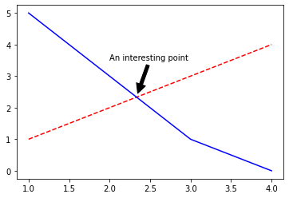

```python
y2=[5, 3, 1, 0]
plt.plot(x,y,'r--',x,y2, 'b-')
plt.annotate('An interesting point', xy=(2.34, 2.4), xytext=(2, 3.5),arrowprops=dict(facecolor='black', shrink=0.05))
plt.show()
```

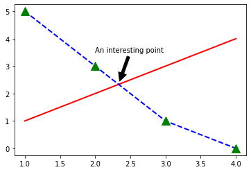

```python
y2=[5, 3, 1, 0]
y3=[5, 3, 1, 0]
plt.plot(x,y,'r-',x,y2, 'b--',x,y3, 'g^',linewidth=2, markersize=12)
plt.annotate('An interesting point', xy=(2.34, 2.4), xytext=(2, 3.5),arrowprops=dict(facecolor='black', shrink=0.05))
plt.show()
```

# Set types

[Set types](https://docs.python.org/3/library/stdtypes.html#set-types-set-frozenset) are

- **unorderded** collections of **distinct** elements
- useful to
  - eliminate replicas from lists,
  - check membership to a set of elements,
  - compute mathematical operations on sets

```python
l=[1,2,3,4,1,2,5]
s = set(l)
print(s)
l_without_replicas=list(s)
l_without_replicas2=[x for x in s]
print(l_without_replicas)
print(l_without_replicas2)

s2 = set([5,4,3,2,1])
print(s2)
print(s==s2)
```

```
{1, 2, 3, 4, 5}
[1, 2, 3, 4, 5]
[1, 2, 3, 4, 5]
{1, 2, 3, 4, 5}
True
```

```python
s={1,2,3}
s2={2,3,4}
print(1 in s)
print(1 in s2)
print('Are s and s2 disjoint?',s.isdisjoint(s2))
print({1,2}.issubset(s))
sunion=s.union(s2)
print(sunion)
```

```
True
False
Are s and s2 disjoint? False
True
{1, 2, 3, 4}
```

For more methods of sets

```python
#dir(lst)
```

You can't access elements by position:

- There is no order in a set!

```python
#s[0] #THIS WOULD GIVE A RUNTIME ERROR!
```

There exists al an immutable version of sets: `frozenset`

- Can be used as key in dictionaries

```python
fs=frozenset([1,2,3])
print(fs)
```

```
frozenset({1, 2, 3})
```

# Mapping Types

A [mapping object](https://docs.python.org/3/library/stdtypes.html#mapping-types-dict) allows to **map**

- elements of one type (the **key**) to
- elemennts of another tpye (the **value**)

Intuitively,

- a list implicitly allows to map integers (the index) to its elements
- a mapping type allows to explicitly define key values of desired type

```python
lst=['a','b','c']
key=1
print('Integer',key,'     is mapped to char',lst[key])

marks={'Andrea': 30, 'Daniele':30, 'Giulio':25}
key='Andrea'
print('Student',key,'is mapped to mark',marks[key])
```

```
Integer 1      is mapped to char b
Student Andrea is mapped to mark 30
```

What mapping types are we going to use?

- **Dictionaries**

```python
type(marks)
```

```
dict
```

These will create the same dict

```python
marks={'Andrea': 30, 'Daniele':30, 'Giulio':25}
marks2=dict(Andrea=30,Daniele=30,Giulio=25)
marks3=dict(zip(['Andrea','Daniele','Giulio'],[30,30,25]))
marks4=dict([('Andrea', 30), ('Daniele', 30), ('Giulio', 25)])
print(marks==marks2==marks3==marks4)
```

```
True
```

Many types can be used as keys. But only those **hashable**

- No mutable collections (list, set, dictionaries)

Some functionalities of dictionaries

```python
print('All keys:',list(marks.keys()))
print('All values:',list(marks.values()))
print('Number of elements:',len(marks))
marks['Andrea']=29
print(marks)
```

```
All keys: ['Andrea', 'Daniele', 'Giulio']
All values: [30, 30, 25]
Number of elements: 3
{'Andrea': 29, 'Daniele': 30, 'Giulio': 25}
```

# Next class...

```python
from IPython.display import Video, display
video=Video('images/loops.mp4')
display(video)
```

[video not shown]

In the next class we will see how to instruct Python in

- Executing certain instructions only if a given condition holds
- Executing a given number of time certain instructins

For example:

- We have seen how to store collections of data.
- In the next class we will see how to easily access their elements in order

```python
weekdays = ["Mon", "Tue", "Wed", "Thu", "Fri"]
translations = {"Mon" : "Lun", "Tue" : "Mar", "Wed" : "Mer", "Thu" : "Gio", "Fri" : "Ven"}
for i in range(5) :
    print("The day",i,"is",weekdays[i])
    print("Il giorno",i,"e'",translations[weekdays[i]])
    print("")
```

```
The day 0 is Mon
Il giorno 0 e' Lun

The day 1 is Tue
Il giorno 1 e' Mar

The day 2 is Wed
Il giorno 2 e' Mer

The day 3 is Thu
Il giorno 3 e' Gio

The day 4 is Fri
Il giorno 4 e' Ven
```